## **Projeto 4: Explore e resuma os dados**

#### **Autor:** *José Ferraz Neto*

#### **Sumário:**

###### 1. Visão geral do conjunto de dados

###### 2. Análise Univariada

###### 2.1 Qual é a estrutura do conjunto de dados?

###### 2.2 Quais são os principais atributos de interesse deste conjunto de dados?

###### 2.3 Quais outros atributos você acha que podem lhe auxiliar na investigação destes atributos de interesse?

###### 2.4 Você criou novas variáveis a partir dos atributos existentes no conjunto de dados?

###### 2.5 Dos atributos investigados, distribuições incomuns foram encontradas? Você aplicou operações nos dados para limpá-los, ajustá-los ou mudar a forma dos dados? Se sim, por quê?

###### 3. Análise Bivariada

###### 3.1 Discuta sobre alguns dos relacionamentos observados nesta parte da investigação. Como os atributos de interesse variaram no conjunto de dados?

###### 3.2 Você observou algum relacionamento interessante entre os outros atributos (os que não são de interesse)?

###### 3.3 Qual foi o relacionamento mais forte encontrado?

###### 4. Seção de Gráficos Multivariados

###### 4.1 Análise Multivariada

###### 4.1.1 Discuta sobre os relacionamentos observados nesta parte da investigação. Quais atributos que fortaleceram os demais na observação das variáveis de interesse?

###### 4.1.2 Interações surpreendentes e/ou interessantes foram encontradas entre os atributos?

###### 4.1.3 Modelos foram criados usando este conjunto de dados? Discuta sobre os pontos fortes e as limitações do seu modelo.

###### 5. Gráficos Finais e Sumário

###### 5.1 Primeiro Gráfico

###### 5.1.1 Descrição do Primeiro Gráfico

###### 5.2 Segundo Gráfico

###### 5.2.1 Descrição do Segundo Gráfico

###### 5.3 Terceiro Gráfico

###### 5.3.1 Descrição do Terceiro Gráfico

###### 6. Reflexão

###### 7. Bibliografia

#### **1. Visão geral do conjunto de dados**

Este conjunto de dados contém 4898 vinhos brancos com 11 variáveis que representam propriedades físico-químicas de vinhos, mais especificamente da variedade branca. Ao menos 3 especialistas em vinhos avaliaram cada vinho, fornecendo uma nota entre 0 (muito ruim) e 10 (muito excelente). Além disso, para maiores informações sobre o *dataset* deve-se consultar o seguinte [link](https://s3.amazonaws.com/udacity-hosted-downloads/ud651/wineQualityInfo.txt).

Para iniciar a análise, iremos começar pelo carregamento do *dataset* em um dataframe.

```r
wine <- read.csv('wineQualityWhites.csv')
```

Iniciaremos a análise avaliando os tipos de variáveis existentes no dataset. Em seguida, podemos explorar se há variáveis que não possuem valores atribuídos, ou seja, *Non Available Data* (NA’s).

```
## 'data.frame':    4898 obs. of  13 variables:
##  $ X                   : int  1 2 3 4 5 6 7 8 9 10 ...
##  $ fixed.acidity       : num  7 6.3 8.1 7.2 7.2 8.1 6.2 7 6.3 8.1 ...
##  $ volatile.acidity    : num  0.27 0.3 0.28 0.23 0.23 0.28 0.32 0.27 0.3 0.22 ...
##  $ citric.acid         : num  0.36 0.34 0.4 0.32 0.32 0.4 0.16 0.36 0.34 0.43 ...
##  $ residual.sugar      : num  20.7 1.6 6.9 8.5 8.5 6.9 7 20.7 1.6 1.5 ...
##  $ chlorides           : num  0.045 0.049 0.05 0.058 0.058 0.05 0.045 0.045 0.049 0.044 ...
##  $ free.sulfur.dioxide : num  45 14 30 47 47 30 30 45 14 28 ...
##  $ total.sulfur.dioxide: num  170 132 97 186 186 97 136 170 132 129 ...
##  $ density             : num  1.001 0.994 0.995 0.996 0.996 ...
##  $ pH                  : num  3 3.3 3.26 3.19 3.19 3.26 3.18 3 3.3 3.22 ...
##  $ sulphates           : num  0.45 0.49 0.44 0.4 0.4 0.44 0.47 0.45 0.49 0.45 ...
##  $ alcohol             : num  8.8 9.5 10.1 9.9 9.9 10.1 9.6 8.8 9.5 11 ...
##  $ quality             : int  6 6 6 6 6 6 6 6 6 6 ...
```

```
##                      na_count
## X                           0
## fixed.acidity               0
## volatile.acidity            0
## citric.acid                 0
## residual.sugar              0
## chlorides                   0
## free.sulfur.dioxide         0
## total.sulfur.dioxide        0
## density                     0
## pH                          0
## sulphates                   0
## alcohol                     0
## quality                     0
```

Constatando que não será necessário tratar os dados para retirar valores inexistentes no dataset, podemos avaliar algumas características das variáveis por meio de algumas medidas de posição e dispersão.

```
##  fixed.acidity    volatile.acidity  citric.acid     residual.sugar
##  Min.   : 3.800   Min.   :0.0800   Min.   :0.0000   Min.   : 0.600
##  1st Qu.: 6.300   1st Qu.:0.2100   1st Qu.:0.2700   1st Qu.: 1.700
##  Median : 6.800   Median :0.2600   Median :0.3200   Median : 5.200
##  Mean   : 6.855   Mean   :0.2782   Mean   :0.3342   Mean   : 6.391
##  3rd Qu.: 7.300   3rd Qu.:0.3200   3rd Qu.:0.3900   3rd Qu.: 9.900
##  Max.   :14.200   Max.   :1.1000   Max.   :1.6600   Max.   :65.800
##    chlorides       free.sulfur.dioxide total.sulfur.dioxide
##  Min.   :0.00900   Min.   :  2.00      Min.   :  9.0
##  1st Qu.:0.03600   1st Qu.: 23.00      1st Qu.:108.0
##  Median :0.04300   Median : 34.00      Median :134.0
##  Mean   :0.04577   Mean   : 35.31      Mean   :138.4
##  3rd Qu.:0.05000   3rd Qu.: 46.00      3rd Qu.:167.0
##  Max.   :0.34600   Max.   :289.00      Max.   :440.0
##     density             pH          sulphates         alcohol
##  Min.   :0.9871   Min.   :2.720   Min.   :0.2200   Min.   : 8.00
##  1st Qu.:0.9917   1st Qu.:3.090   1st Qu.:0.4100   1st Qu.: 9.50
##  Median :0.9937   Median :3.180   Median :0.4700   Median :10.40
##  Mean   :0.9940   Mean   :3.188   Mean   :0.4898   Mean   :10.51
##  3rd Qu.:0.9961   3rd Qu.:3.280   3rd Qu.:0.5500   3rd Qu.:11.40
##  Max.   :1.0390   Max.   :3.820   Max.   :1.0800   Max.   :14.20
##     quality
##  Min.   :3.000
##  1st Qu.:5.000
##  Median :6.000
##  Mean   :5.878
##  3rd Qu.:6.000
##  Max.   :9.000
```

Após uma análise do sumário acima, é possível constatar que algumas variáveis possuem valores máximos e mínimos muito díspares em relação as suas respectivas médias e/ou medianas, por exemplo, `fixed.acidity`, `free.sulfur.dioxide`, entre outras. Diante dos fatos, é prudente realizarmos uma análise exploratória por meio de boxplots em cada variável.  
É possível observar que existem algumas variáveis que possuem muitas observações que encontram-se fora do intervalo interquartil (IQR), isto é, abaixo do primeiro quartil ou acima do terceiro quartil, como é o caso da variável `chlorides`.

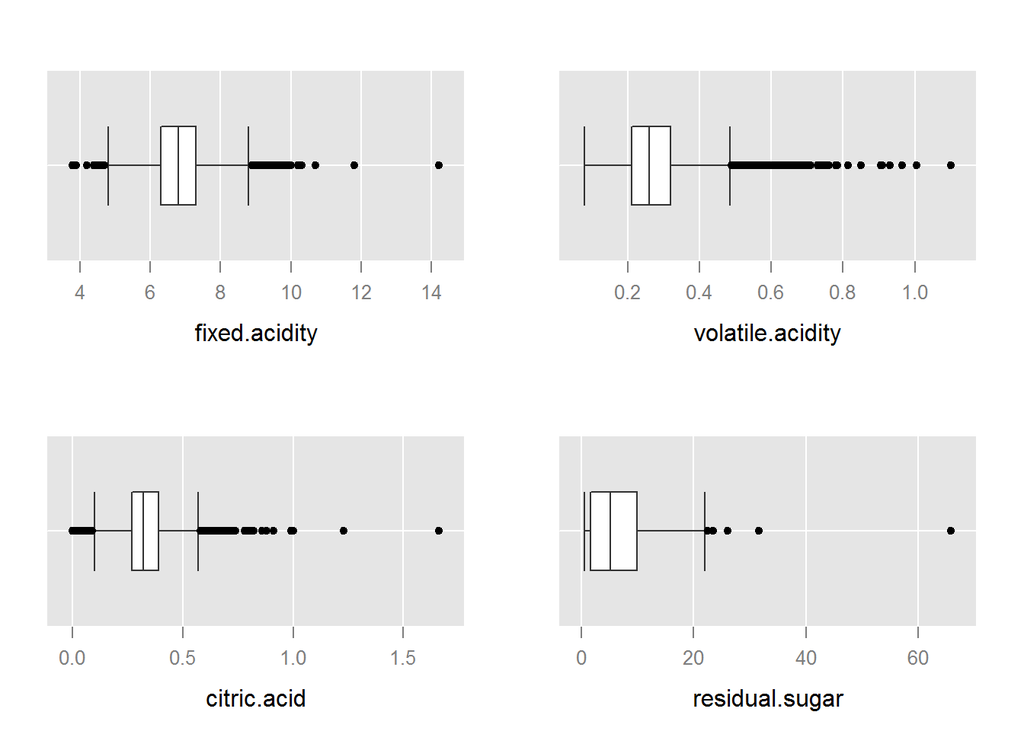

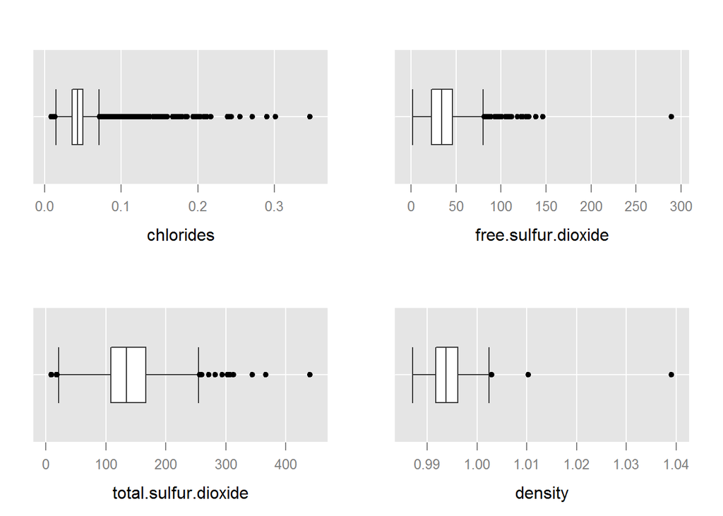

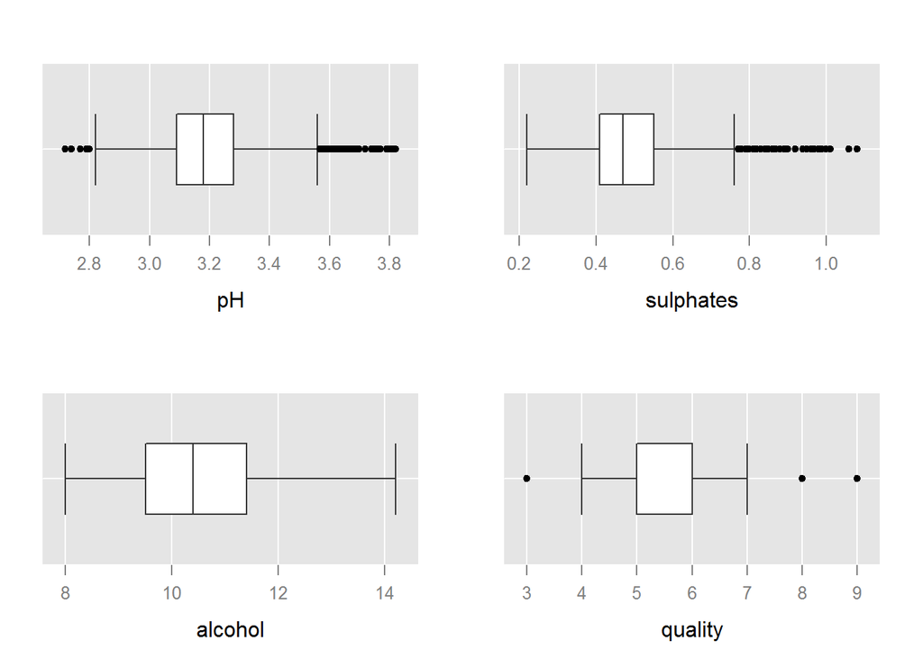

Como observado acima, há situações no qual o boxplot apresenta um *overplotting* na região externa ao IQR, assim não é possível quantificar pelo gráfico o total de observações que estão fora do IQR. Desse modo, se torna mais apropriado verificar a distribuição dos valores de uma determinada variável por meio de histogramas.

Pela análise do conjunto de histogramas abaixo, é possível identificar que a existência de regiões com poucas observações, que acabam por distorcer o gráfico, por exemplo as variáveis `volatile.acidity`, `citric.acid` e `residual.sugar`

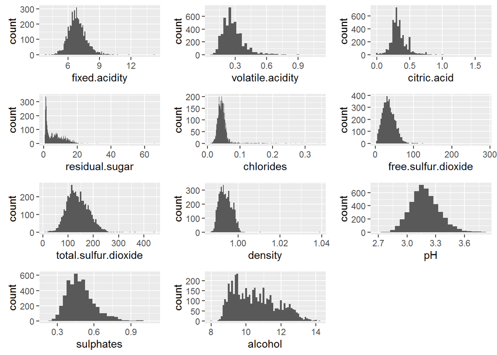

Uma possível justicativa para a presença desse tipo de valores pode ser explicado pela presença de outliers no conjunto de dados. Logo, para melhor avaliar a distribuição de dados dessas variáveis é possível plotar histogramas que contemplem apenas as observações inferiores ao 99° percentil.

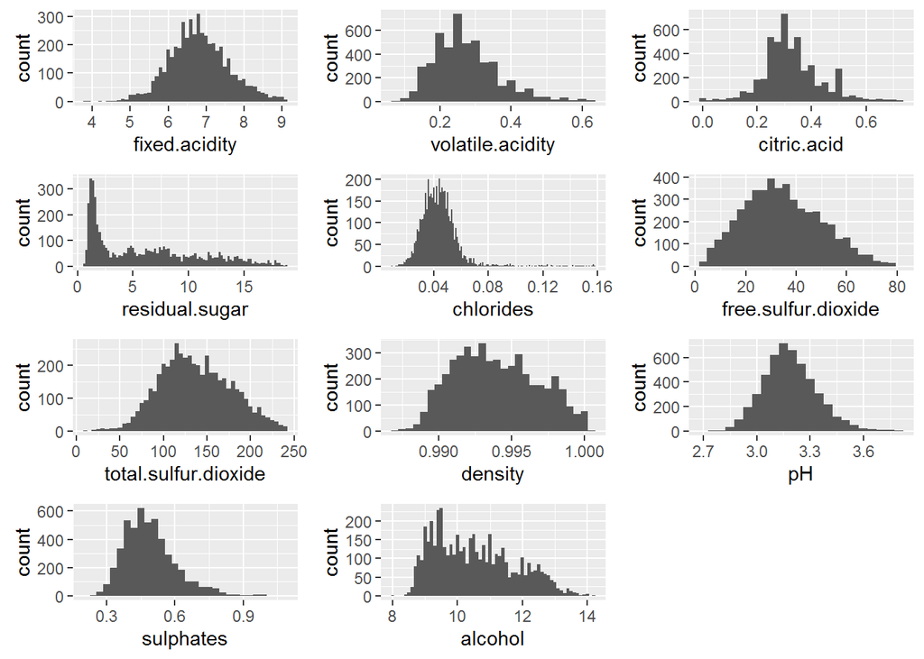

Das variáveis plotadas acima, a maioria dos histogramas aparentam seguir uma distribuição normal, um dos casos que claramente foge a esse padrão é a `residual.sugar` que apresenta uma forte assimetria à direita. Diante disso, é possível tentar uma transformação logaritímica no eixo x para que seja possível mudar essa assimetria nos dados da variável.

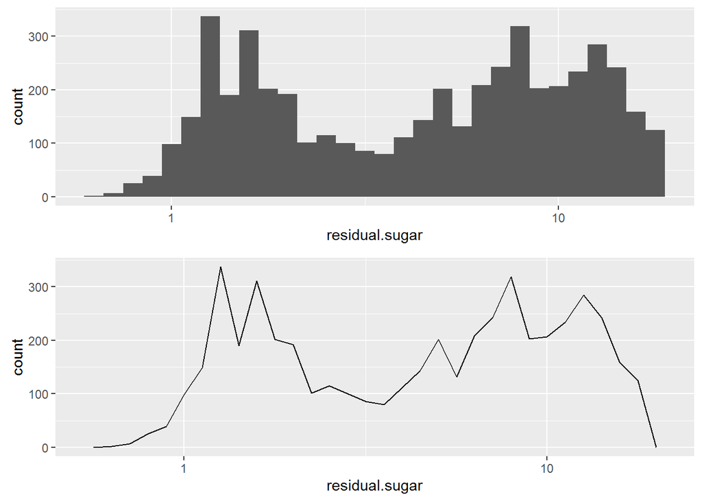

Após a transformação dos dados é possível confirmar que o formato da distribuição em nada se assemelha a normal, e pela presença dos dois picos é mais característico de uma distribuição bimodal. O resultado da plotagem do polígono de frequências reforça esse fato.

Além disso, iremos criar uma segunda variável qualitativa que irá categorizar as bebidas em qualidade “baixa”, “média” e “alta”. Como mostra o resultado abaixo, após a criação da variável `quality.sense` a maioria (3655) dos vinhos estão categorizados como de qualidade Média.

```
## baixa média  alta
##   183  3655  1060
```

O dióxido de enxofre (SO<sub>2</sub>) exerce diversas funções desde agente antioxidante, além da ajudar a preservar o frescor da bebida. O dataset apresenta os teores totais (`total.sulfur.dioxide`) e livre de dióxido de enxofre (`free.sulfur.dioxide`), todavia, é possível determinar a forma ligada ou *bound* da espécie. Assim, iremos criar uma nova variável `bound.sulfur.dioxide`.

```
##    Min. 1st Qu.  Median    Mean 3rd Qu.    Max.
##     4.0    78.0   100.0   103.1   125.0   331.0
```

Em seguida, é possível verificar os gráficos de barra das variáveis `quality` e `quality sense` . Para o caso da primeira a maior parte dos vinhos possuem nota variando de 5 a 7. Além disso, há o gráfico da função de distribuição de probabilidade para as variáveis `total.sulfur.dioxide`, `free.sulfur.dioxide` e `bound.sulfur.dioxide`. É possível identificar que a distribuiçao de `total.sulfur.dioxide` é bem mais dispersa, enquanto a de `free.sulfur.dioxide` muito mais concentrada em um região menor de concentrações.

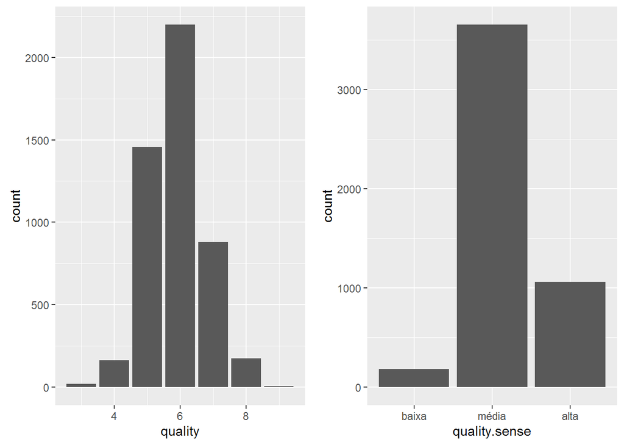

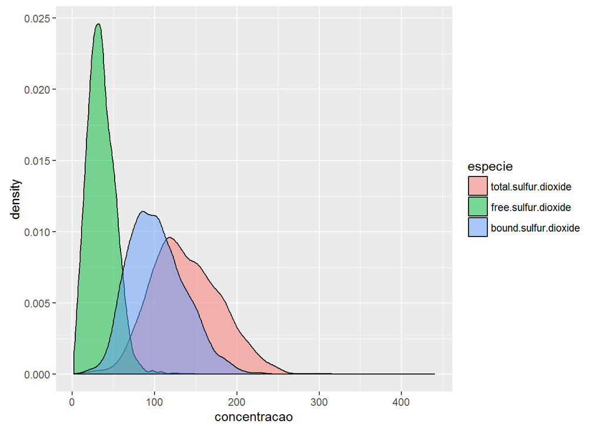

#### **2. Análise Univariada**

##### **2.1 Qual é a estrutura do conjunto de dados?**

Esse conjunto de dados possui 1 variável index `X`, 1 variável reposta `quality` e outras 11 preditoras. Essas últimas são propriedade físico-químicas associadas aos vinhos. A variável resposta é a nota atribuída ao vinho e varia desde 3 até 9, além disso vale ressaltar que a variável `quality` é do tipo discreta ordenada.

##### **2.2 Quais são os principais atributos de interesse deste conjunto de dados?**

O principal atributo desse dataset é a variável resposta `quality` que é a consolidação da qualidade atribuida por um especialista a um determinado vinho. Além disso, após uma análise de correlação entre as variáveis preditoras e a resposta será possível constatar se alguma das propriedades físico-químicas do vinho possuem alguma influência na determinação da qualidade da bebida.

##### **2.3 Quais outros atributos você acha que podem lhe auxiliar na investigação destes atributos de interesse?**

Acredito que uma melhor qualidade dos vinhos poderá estar relacionada as variáveis `alcohol` que determina o teor alcólico da bebida, bem como com o `pH` que é um indicador de acidez do vinho.

##### **2.4 Você criou novas variáveis a partir dos atributos existentes no conjunto de dados?**

Foram criados uma variável qualitativa ordenada baseada nos dados de `quality` denominada `quality.sense` e os respectivos níveis são: baixa, média e alta. Além disso, foi criado a variável `bound.sulfur.dioxide` que representa a concentração de outra espécie química de dióxido de enxofre.

##### **2.5 Dos atributos investigados, distribuições incomuns foram encontradas? Você aplicou operações nos dados para limpá-los, ajustá-los ou mudar a forma dos dados? Se sim, por quê?**

Das variáveis preditoras a única que muito diferiu da normalidade, foi a `residual.sugar` que possui uma forte assimetria à direita. De modo a minimizar essa distorçar foi realizado uma transformação logaritímica no eixo x, resultado em uma distribuição similar a uma bimodal. Além disso, na plotagem dos histogramas para melhor ajustar os dados foram retirados o 1° percentil superior de cada variável de modo a melhor visualizar as respectivas distribuições, resultando em gráficos semelhantes aos esperados por uma distribuição normal.

#### **3. Análise Bivariada**

##### **3.1 Discuta sobre alguns dos relacionamentos observados nesta parte da investigação. Como os atributos de interesse variaram no conjunto de dados?**

A seguir iremos explorar possíveis associações entre as diversas variáveis disponíveis no dataset, para esse fim iremos utilizar um plot de correlação que sumariza o coeficiente de pearson entre as variáveis de interesse. A partir da análise do gráfico abaixo, é possível constarar uma forte correlação positiva entre os pares (`residual.sugar` e `density`) e (`total.sulfur.dioxide` e `free.sulfur.dioxide`), por exemplo. Além disso, em relação as variáveis preditoras e a variável resposta `quality`, aquela que apresenta o maior coefieciente de correlação foi `alcohol`.

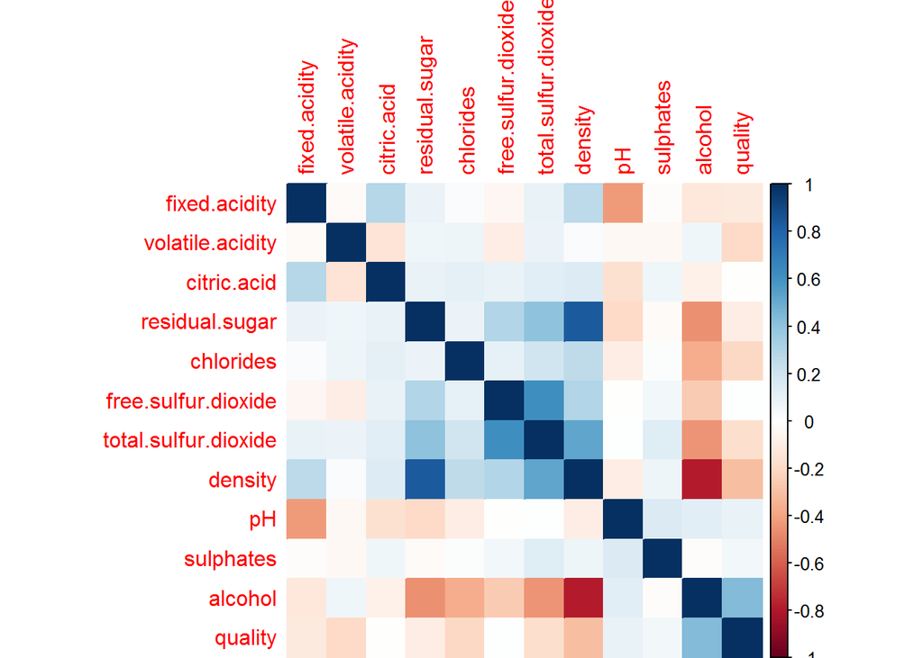

Após uma leitura do gráfico é possível constatar uma forte correlação positiva entre as variáveis:

- `residual.sugar` e `density` : 0.8389665
- `free.sulfur.dioxide` e `total.sulfur.dioxide`: 0.615501
- `quality` e `alcohol`: 0.4355747

Além disso, é válido descatar uma forte correlação negativa entre:

- `alcohol` e `density`: -0.7801376

Por conseguinte, é possível produzir uma matriz de gráficos de dispersão onde verifica-se em um única visualização o padrão de comportamento dos dados de múltiplas variáveis. A partir de uma primeira análise, é possível confirmar um bom ajuste para um modelo linear para as variáveis `residual.sugar` e `density` , corroborando o alto valor do coeficiante de correlação previamente mencionado. Além de `alcohol` e `density` que os dados claramente confirmam a relação inversa existente entre essas variáveis. As demais variáveis analisadas aparentemente não apresentam nenhum padrão a ser destacado nessa matriz.

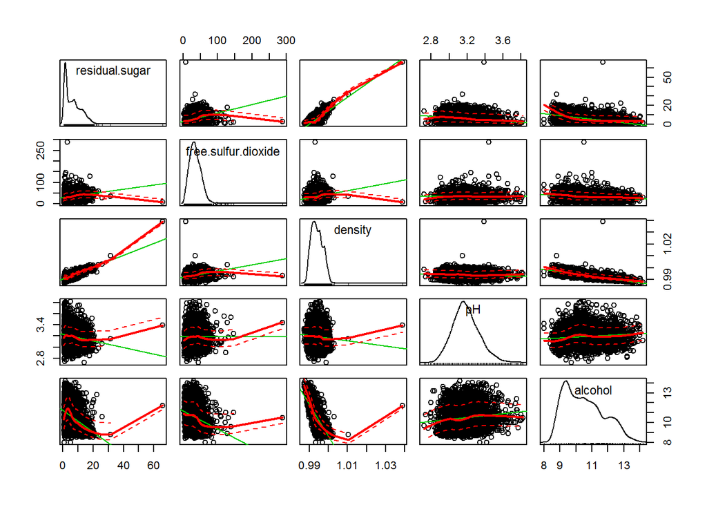

A matriz de gráficos de dispersão é eficiente para uma análise exploratória prévia, todavia, é mais aconselhável plotar gráficos individuais para melhor avaliar a relação entre duas variáveis. O gráfico de dispersão abaixo foi plotado retirando o 5° percentil superior de ambas as variáveis e pode-se verificar que apresenta um ajuste razoável para um modelo de regressão linear.

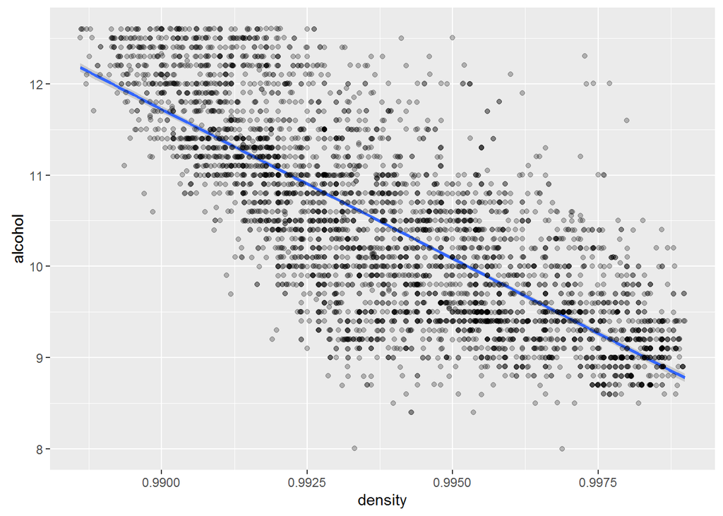

O gráfico abaixo apresenta uma tendência de crescimento dos dados de `residual.sugar` e `density`, todavia, há um platô de pontos abaixo de 2.5 g / dm<sup>3</sup> de `residual.sugar` que claramente distorce da tendência do restante do conjunto de dados.

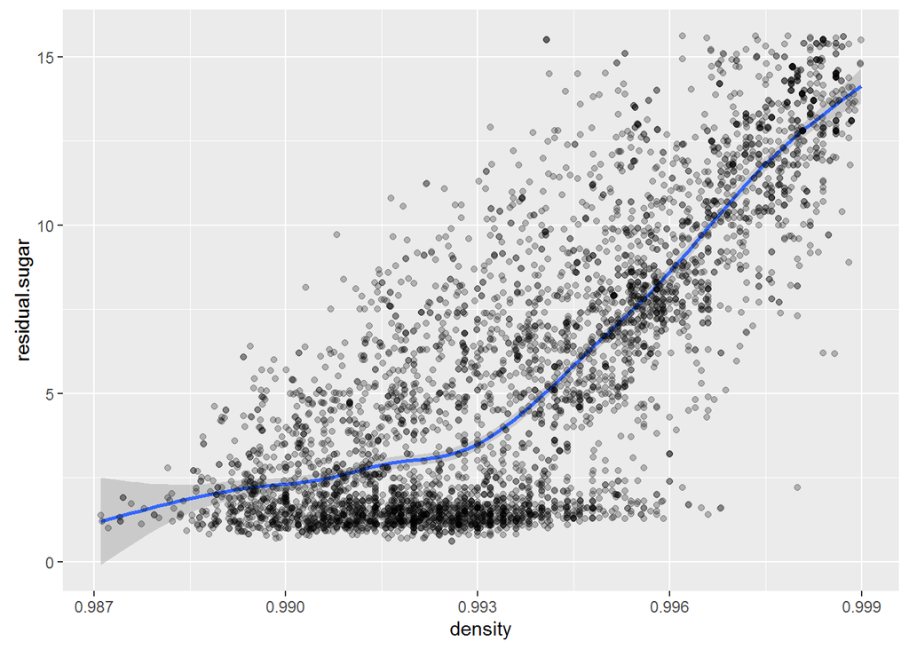

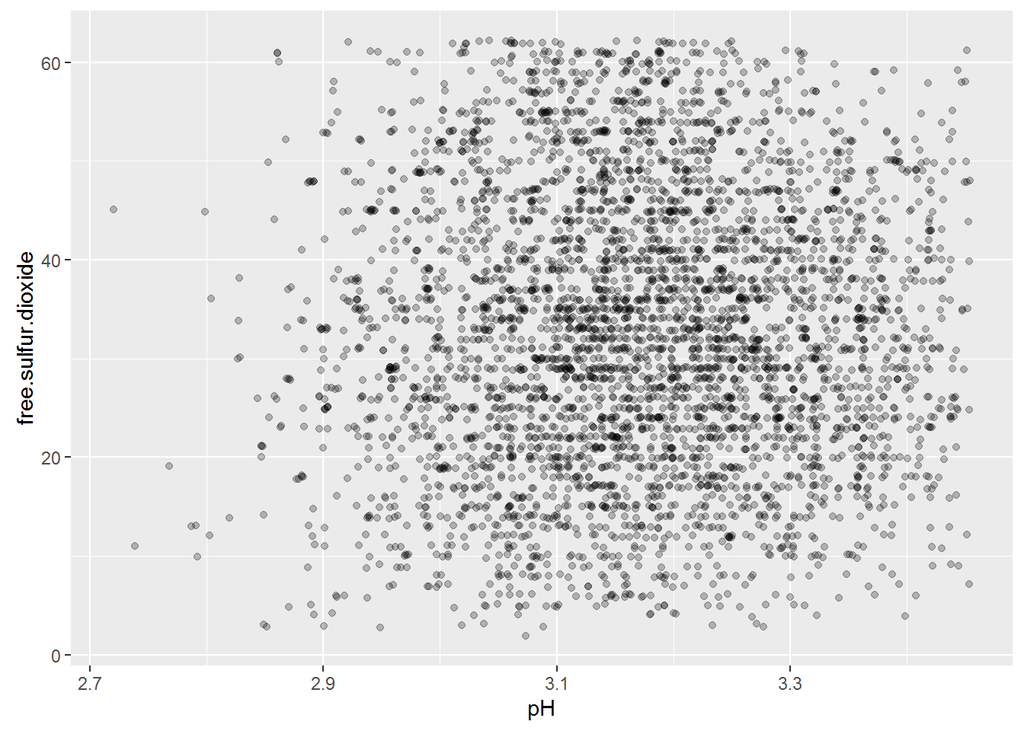

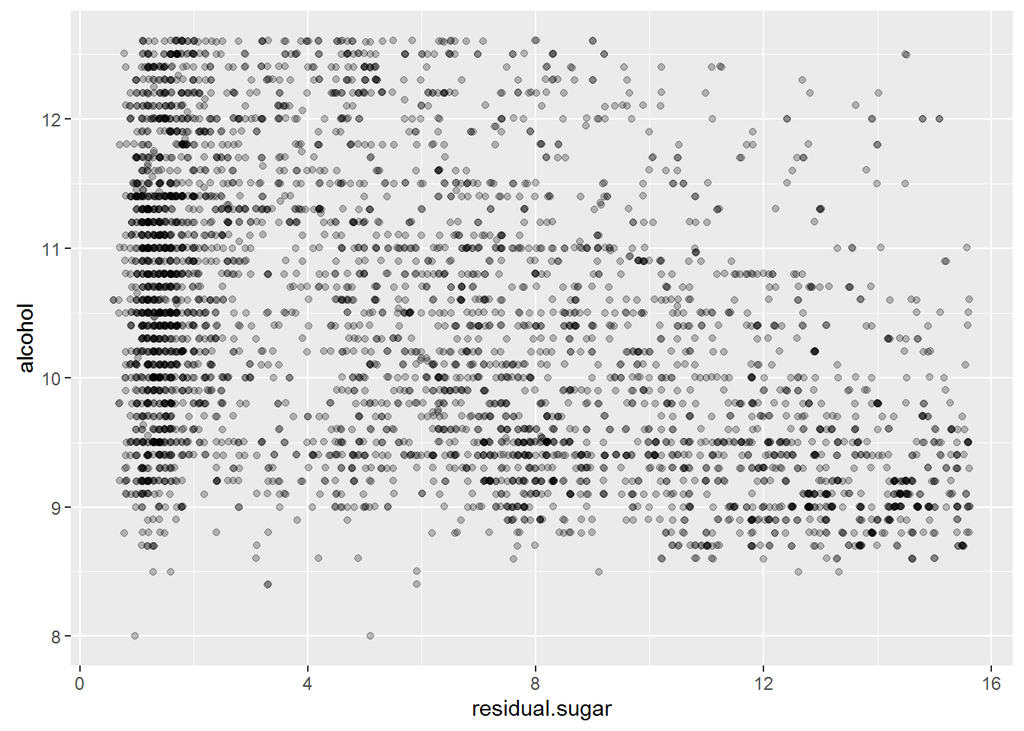

Por uma plotagem de boxplots é possível determinar algumas tendências interessantes. O primeiro gráfico é de `alcohol` vs `quality` que apresenta uma tendêcia de crescimento da mediana do teor de álcool com a qualidade do vinho. Enquanto o segundo apresenta uma plotagem de `total.sulfur.dioxide` vs `quality` o qual a mediana da concentração total de dióxido de enxofre possui uma tendência de estabilização da mediana ao longo dos diferentes graus de qualidade, todavia, o IQR parece diminuir a medida que a qualidade dos vinhos aumenta, isto é, a maior parte dos vinhos de maior qualidade possui uma faixa de concentração total de dióxido de enxofre menos dispersa que aqueles vinhos de menor qualidade.

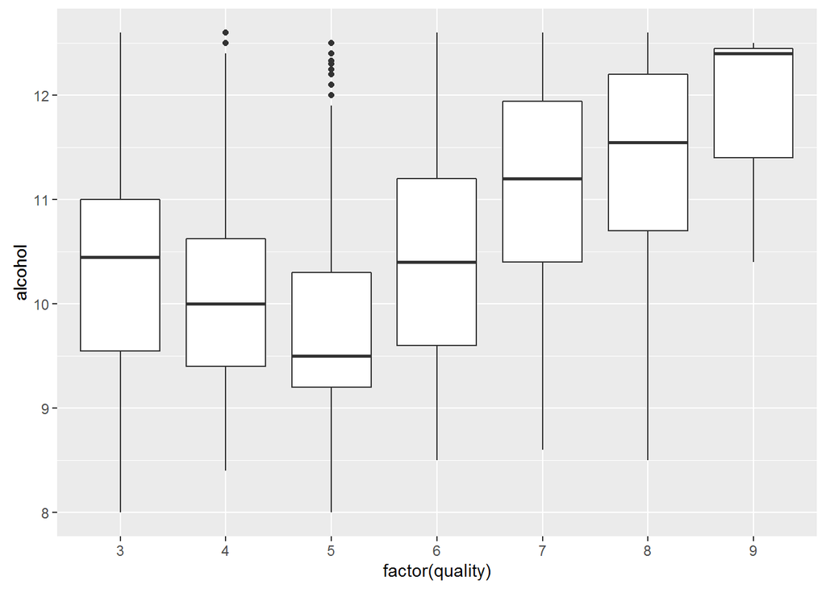

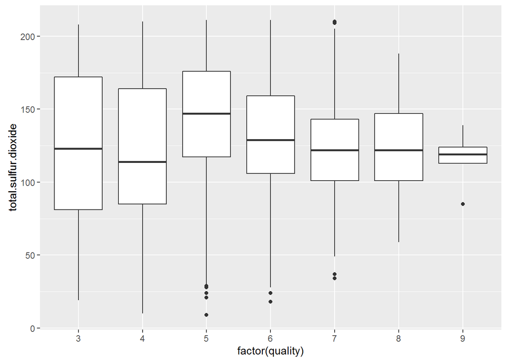

##### **3.2 Você observou algum relacionamento interessante entre os outros atributos (os que não são de interesse)?**

Pelos gráficos de dispersão acima é possível visualizar a correlação negativa existentes entre `alcohol` e `density`, a medida que o teor de álcool dos vinhos decresce, uma clara tendência da densidade das respectivas bebidas aumentar. De forma contrária, as variáveis `residual.sugar` e `density` apresentam uma tendência que o acréscimo em uma variável, em sua maioria corresponde a um acréscimo também nos valores de densidade dos vinhos.

Além disso, o boxplot de `alcohol` e `quality` apresenta algumas informações relevantes. Os vinhos que receberam uma nota 9 em `quality` são aqueles que apresentam a maior mediana para `alcohol` dentre todos os vinhos, enquanto aqueles que receberam uma nota 5 em `quality` possuem a menor mediana para `alcohol` dentre todos.

A plotagem de um histograma de `alcohol` segregando por nota recebida em `quality` pode nos ajudar a dicernir se as informações contidas no boxplot obtido pela amostragem obtida no dataset estudado podem ser estrapoladas para uma população de vinhos. O histograma abaixo revela que os vinhos que receberam 9 em sua avaliação são pouquíssimos, portanto, afirmar que os vinhos melhor avaliados possuem de fato uma mediana de `alcohol` superior aos demais, é no mínimo, temerário, pela provável não representativa da amostragem em relação a sua população.

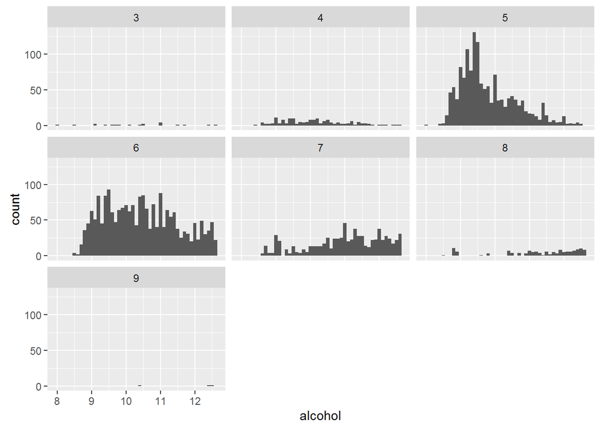

Em relação a variável `residual sugar` abaixo está o histograma destacado para as diferentes categorias de `quality.sense` e a característica bimodal da distribuição permanece mesmo quando separado por categoria de avaliação de `quality.sense`.

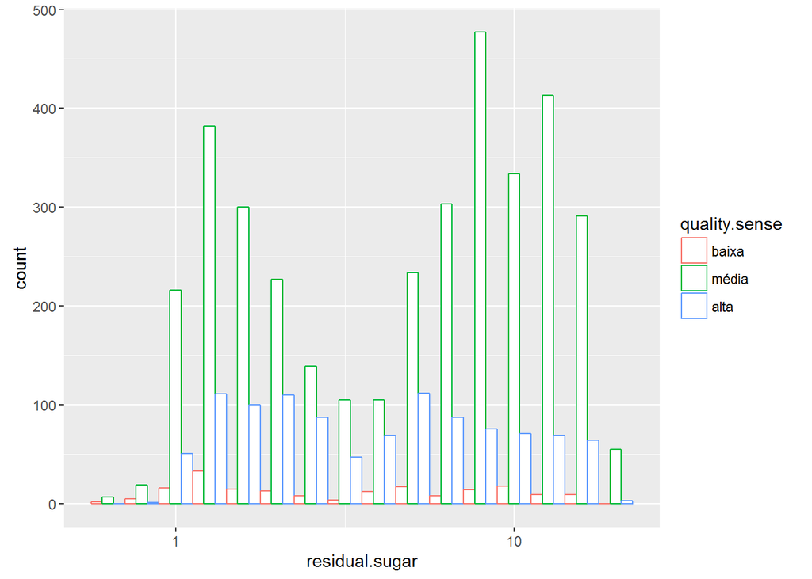

##### **3.3 Qual foi o relacionamento mais forte encontrado?**

As variáveis mais fortemente correlacionadas foram: `residual.sugar` e `density`: 0.8389665

#### **4. Seção de Gráficos Multivariados**

A partir de gráficos multivaridos é possível determinar possíveis relações de múltiplas variáveis. Abaixo está plotado um gráfico de dispersão de `alcohol` vs `pH` no qual foi adicionado um terceira dimensão por meio da codificação em cores da variável `quality.sense`. Todavia, não possível determinar nenhuma segregação de qualidade baseada nas variáveis preditoras plotadas.

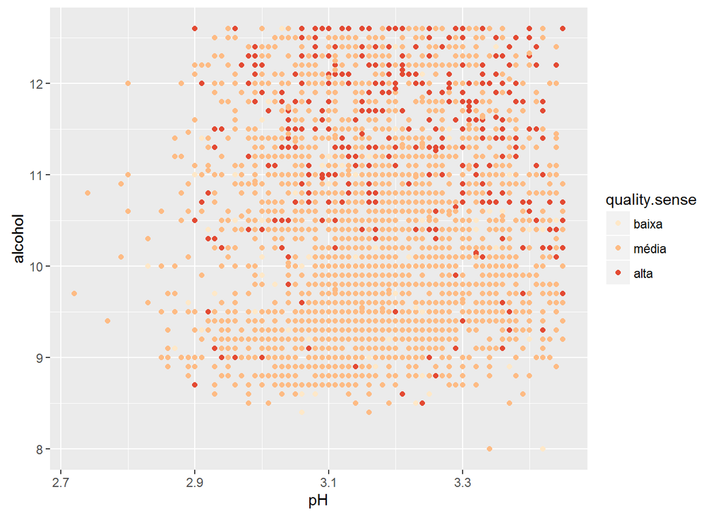

O gráfico abaixo apresenta uma tendência dos vinhos avaliados como alta estarem concentrados em maiores teores de `alcohol` .

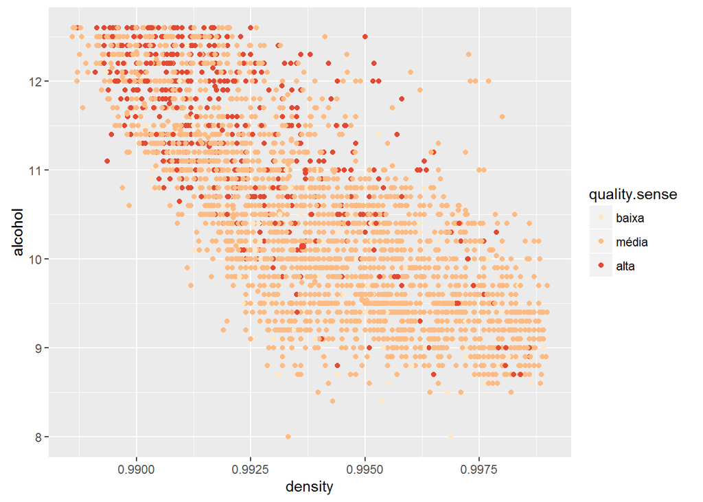

Com o gráfico de dispersão abaixo é possível identificar que a maior parte dos vinhos melhores avaliados possuem valores de `density` menores que 0.993.

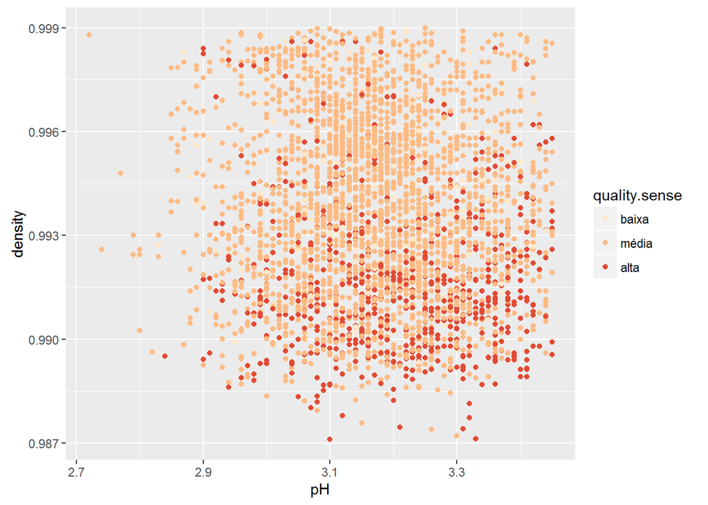

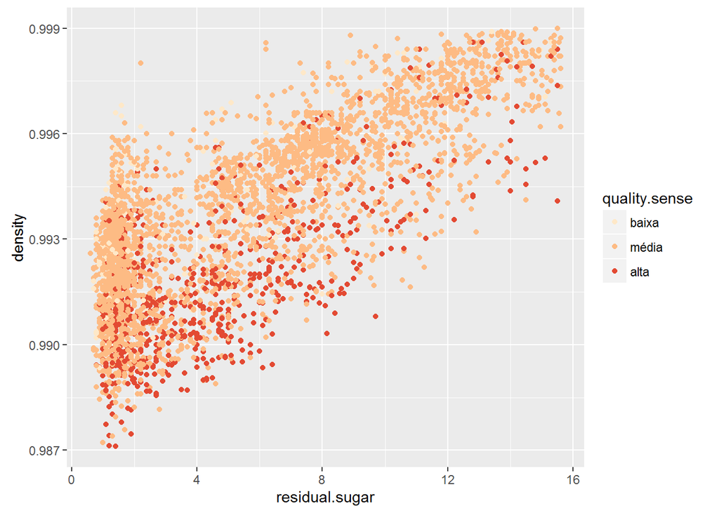

Nesse gráfico não há nehum padrão entre as variáveis plotadas nos eixos x/y e tão pouco em relação a variável codificada pelas cores da legenda.

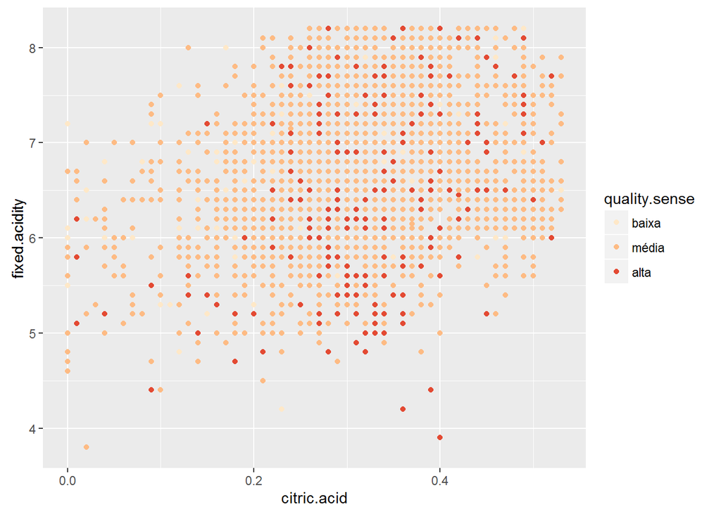

Apesar da tendência de crescimento apresentada pelo gráfico de dispersão abaixo, não é possível identificar nenhuma tendência de segregação em relação a variável `quality.sense`.

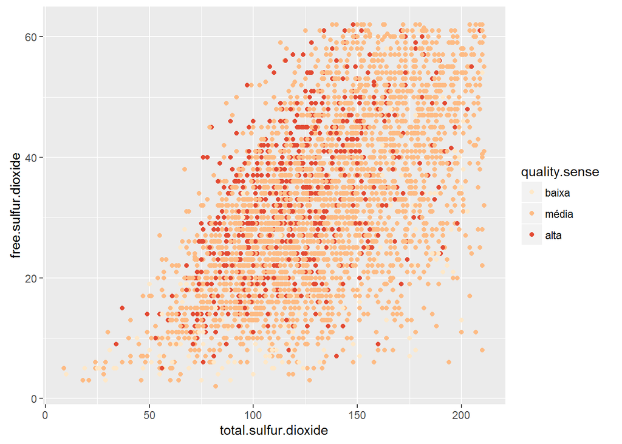

#### **4.1 Análise Multivariada**

Para criarmos um modelo de regressão linear múltiplo, iremos criar versões centradas na média para todas as variáveis preditoras. Esse novo conjunto de variáveis irão terminar em **.center** em seus nomes. Essa transformação tem o objetivo que seja possível obter uma interpretação significativa do valor estimado para o intercepto do modelo. Em seguida, é possível verificar um sumário de medidas de posição e dispersão para esse novo conjunto de variáveis.

```
##     quality      fixed.acidity.center volatile.acidity.center
##  Min.   :3.000   Min.   :-3.05479     Min.   :-0.19824
##  1st Qu.:5.000   1st Qu.:-0.55479     1st Qu.:-0.06824
##  Median :6.000   Median :-0.05479     Median :-0.01824
##  Mean   :5.878   Mean   : 0.00000     Mean   : 0.00000
##  3rd Qu.:6.000   3rd Qu.: 0.44521     3rd Qu.: 0.04176
##  Max.   :9.000   Max.   : 7.34521     Max.   : 0.82176
##  citric.acid.center residual.sugar.center chlorides.center
##  Min.   :-0.33419   Min.   :-5.791        Min.   :-0.036772
##  1st Qu.:-0.06419   1st Qu.:-4.691        1st Qu.:-0.009772
##  Median :-0.01419   Median :-1.191        Median :-0.002772
##  Mean   : 0.00000   Mean   : 0.000        Mean   : 0.000000
##  3rd Qu.: 0.05581   3rd Qu.: 3.509        3rd Qu.: 0.004228
##  Max.   : 1.32581   Max.   :59.409        Max.   : 0.300228
##  free.sulfur.dioxide.center total.sulfur.dioxide.center
##  Min.   :-33.308            Min.   :-129.361
##  1st Qu.:-12.308            1st Qu.: -30.361
##  Median : -1.308            Median :  -4.361
##  Mean   :  0.000            Mean   :   0.000
##  3rd Qu.: 10.692            3rd Qu.:  28.639
##  Max.   :253.692            Max.   : 301.639
##  density.center         pH.center         sulphates.center
##  Min.   :-0.0069174   Min.   :-0.468267   Min.   :-0.26985
##  1st Qu.:-0.0023049   1st Qu.:-0.098267   1st Qu.:-0.07985
##  Median :-0.0002874   Median :-0.008267   Median :-0.01985
##  Mean   : 0.0000000   Mean   : 0.000000   Mean   : 0.00000
##  3rd Qu.: 0.0020726   3rd Qu.: 0.091733   3rd Qu.: 0.06015
##  Max.   : 0.0449526   Max.   : 0.631733   Max.   : 0.59015
##  alcohol.center
##  Min.   :-2.5143
##  1st Qu.:-1.0143
##  Median :-0.1143
##  Mean   : 0.0000
##  3rd Qu.: 0.8857
##  Max.   : 3.6857
```

Primeiramente, iremos criar um modelo univariado com a preditora que possui o maior valor do coeficiente de correlação, `alcohol`. Em seguida, iremos criar um modelo de regressão múltipla com todas as variáveis preditoras centradas pela média.

##### `Modelo 1.`

```
##
## Call:
## lm(formula = quality ~ alcohol, data = wine)
##
## Residuals:
##     Min      1Q  Median      3Q     Max
## -3.5317 -0.5286  0.0012  0.4996  3.1579
##
## Coefficients:
##             Estimate Std. Error t value Pr(>|t|)
## (Intercept) 2.582009   0.098008   26.34   <2e-16 ***
## alcohol     0.313469   0.009258   33.86   <2e-16 ***
## ---
## Signif. codes:  0 '***' 0.001 '**' 0.01 '*' 0.05 '.' 0.1 ' ' 1
##
## Residual standard error: 0.7973 on 4896 degrees of freedom
## Multiple R-squared:  0.1897, Adjusted R-squared:  0.1896
## F-statistic:  1146 on 1 and 4896 DF,  p-value: < 2.2e-16
```

##### `Modelo 2.`

```
##
## Call:
## lm(formula = quality ~ fixed.acidity.center + volatile.acidity.center +
##     citric.acid.center + residual.sugar.center + chlorides.center +
##     free.sulfur.dioxide.center + total.sulfur.dioxide.center +
##     density.center + pH.center + sulphates.center + alcohol.center,
##     data = centerset)
##
## Residuals:
##     Min      1Q  Median      3Q     Max
## -3.8348 -0.4934 -0.0379  0.4637  3.1143
##
## Coefficients:
##                               Estimate Std. Error t value Pr(>|t|)
## (Intercept)                  5.878e+00  1.074e-02 547.502  < 2e-16 ***
## fixed.acidity.center         6.552e-02  2.087e-02   3.139  0.00171 **
## volatile.acidity.center     -1.863e+00  1.138e-01 -16.373  < 2e-16 ***
## citric.acid.center           2.209e-02  9.577e-02   0.231  0.81759
## residual.sugar.center        8.148e-02  7.527e-03  10.825  < 2e-16 ***
## chlorides.center            -2.473e-01  5.465e-01  -0.452  0.65097
## free.sulfur.dioxide.center   3.733e-03  8.441e-04   4.422 9.99e-06 ***
## total.sulfur.dioxide.center -2.857e-04  3.781e-04  -0.756  0.44979
## density.center              -1.503e+02  1.907e+01  -7.879 4.04e-15 ***
## pH.center                    6.863e-01  1.054e-01   6.513 8.10e-11 ***
## sulphates.center             6.315e-01  1.004e-01   6.291 3.44e-10 ***
## alcohol.center               1.935e-01  2.422e-02   7.988 1.70e-15 ***
## ---
## Signif. codes:  0 '***' 0.001 '**' 0.01 '*' 0.05 '.' 0.1 ' ' 1
##
## Residual standard error: 0.7514 on 4886 degrees of freedom
## Multiple R-squared:  0.2819, Adjusted R-squared:  0.2803
## F-statistic: 174.3 on 11 and 4886 DF,  p-value: < 2.2e-16
```

##### `Modelo 3.`

```
##
## Call:
## lm(formula = quality ~ fixed.acidity.center + volatile.acidity.center +
##     residual.sugar.center + free.sulfur.dioxide.center + density.center +
##     pH.center + sulphates.center + alcohol.center, data = centerset)
##
## Residuals:
##     Min      1Q  Median      3Q     Max
## -3.8246 -0.4938 -0.0396  0.4660  3.1208
##
## Coefficients:
##                              Estimate Std. Error t value Pr(>|t|)
## (Intercept)                 5.878e+00  1.073e-02 547.625  < 2e-16 ***
## fixed.acidity.center        6.810e-02  2.043e-02   3.333 0.000864 ***
## volatile.acidity.center    -1.888e+00  1.095e-01 -17.242  < 2e-16 ***
## residual.sugar.center       8.285e-02  7.287e-03  11.370  < 2e-16 ***
## free.sulfur.dioxide.center  3.349e-03  6.766e-04   4.950 7.67e-07 ***
## density.center             -1.543e+02  1.834e+01  -8.411  < 2e-16 ***
## pH.center                   6.942e-01  1.034e-01   6.717 2.07e-11 ***
## sulphates.center            6.285e-01  9.997e-02   6.287 3.52e-10 ***
## alcohol.center              1.932e-01  2.408e-02   8.021 1.31e-15 ***
## ---
## Signif. codes:  0 '***' 0.001 '**' 0.01 '*' 0.05 '.' 0.1 ' ' 1
##
## Residual standard error: 0.7512 on 4889 degrees of freedom
## Multiple R-squared:  0.2818, Adjusted R-squared:  0.2806
## F-statistic: 239.7 on 8 and 4889 DF,  p-value: < 2.2e-16
```

##### **4.1.1 Discuta sobre os relacionamentos observados nesta parte da investigação. Quais atributos que fortaleceram os demais na observação das variáveis de interesse?**

Foram avaliados algumas relações entre as diferentes variáveis preditoras, bem como entre essas e a variável resposta. Foi observado uma relação negativa entre `alcohol` e `density` em que valores elevados de `alcohol` estão associados a menores valores de `density`. Além disso, pode-se observar que vinhos que possuem classificação **alta** em `quality.sense` tendem a possuir valores mais elevados de `alcohol` e consequentemente menores valores de `density`.

De forma similar, apesar do elevado coeficiente de correlação entre `free.sulfur.dioxide` e `total.sulfur.dioxide` não observou-se nenhum padrão em relação aos diferentes níveis de `quality.sense`. Dessa forma, é possível cogitar que as relações existentes por essas variáveis preditoras não são explicadas pela qualidade do vinho.

##### **4.1.2 Interações surpreendentes e/ou interessantes foram encontradas entre os atributos?**

Foi surpreendente observar que dez das onze variáveis preditoras possuem coeficientes de correlação próximos de zero ou mesmo negativo em relação a variável resposta `quality`. Além disso, a variável `alcohol` estar positivamente correlacionada a qualidade em um primeiro momento parece ser contrassensual, porque não necessariamente altos teores álcoolicos estão associados a um sabor sensorialmente agradável. Todavia, essa relação entre `alcohol`/`quality` pode ser mais um exemplo da máxima que diz: **correlação não implica por si só em causalidade**, isto é, um vinho ser categorizado com uma boa nota não implica que essa qualidade tenha sido atribuída devido a um elevado teor alcoólico.

##### **4.1.3 Modelos foram criados usando este conjunto de dados? Discuta sobre os pontos fortes e as limitações do seu modelo.**

Foram criados ao todo 3 modelos, no qual o primeiro foi uma regressão linear de `quality` e `alcohol` que apresentou um R<sup>2</sup> de apenas 0.1897, isto é, apenas 18.97% da variância apresentada pela variável resposta `quality` pode ser explicada pela variável preditora `alcohol` . Essa estatística revela que o modelo criado não é adequado para modelar os dados e predizer com acurácia a qualidade dos vinhos.

A partir da constatação que o modelo linear baseado apenas em `alcohol` não foi efetivo, propomos um modelo de regressão linear múltipla baseada em todas as variáveis preditoras disponíveis no dataset. Por conseguinte, foi realizado uma transformação nas variáveis de modo a deixá-las centradas pela média.

Assim, o `modelo 2` obteve um R<sup>2</sup><sub>adj</sub> de 0.2803 que é levemente superior ao obtido pelo modelo univariado. Além disso, o intercepto do modelo nos informa que um vinho terá uma nota média de 5.878 quando todas as variáveis preditoras do modelo tiverem seus respectivos valores médios.

Além disso, o *Residual Standard Error* que é uma medida da qualidade do ajuste da regressão linear registrou o valor de 0.7514 que é uma medida de quão distante a nota de `quality` prevista pelo modelo desvia da linha de regressão verdadeira. Dessa maneira, como a nota média de todos vinhos é 5.878 e o *Residual Standard Error* é 0.7514 podemos afirmar que o erro percentual dos valores preditos pelo modelo é de 12.78%.

Dos parâmetros disponíveis para avaliar o ajuste do modelo, a *F-Statistic* é um indicador se há relação entre as variáveis preditoras e a variável resposta, nesse contexto quão maior que um for o número, melhor. Dessa forma, o `modelo 2` obteve uma *F-Statistic* de 174.3 que é um bom indicativo do ajuste do modelo.

No sumário de avaliação dos coeficientes das variáveis preditores há o atributo *Pr(>|t|)*, que deve ser interpretado com a probabilidade de observamos uma possível relação entre o preditor e a resposta devido simplesmente a sorte, ou seja, quão menor esse número for, melhor, pois mais improvável será que a relação seja devido a sorte. Normalmente, se confronta o valor com um nível de significância de 5%. Assim, constatamos que as variáveis `citric.acid.center`, `chlorides.center` e `total.sulfur.dioxide.center` possuem o *Pr(>|t|)* maior que 5%. Desse modo, foi criado um `modelo 3` que não possui essas variáveis na modelagem.

Ao analisarmos o output do `modelo 3` verficamos que todas as variáveis preditoras possuem *Pr(>|t|)* menor que o nível de significância adotado, além disso a *F-Statistic* subiu de 174.3 para 239.7, além disso, o R<sup>2</sup><sub>adj</sub> aumentou de 0.2803 e 0.2806. Além disso, o *Residual Standard Error* reduziu de 0.7514 para 0.7512 também uma mudança discreta.

Dessa forma, mesmo com uma melhora do modelo ainda não temos um bom ajuste destes aos dados. Assim, acredito que isso revele uma relação não linear entre as variáveis preditoras e a resposta. Por fim, uma possível melhora, seja aumentar a amostragem do dataset ou ainda buscar transformações nas variáveis disponíveis de modo a buscar uma melhora na relação entre essas e a variável resposta.

#### **5. Gráficos Finais e Sumário**

##### **5.1 Primeiro Gráfico**

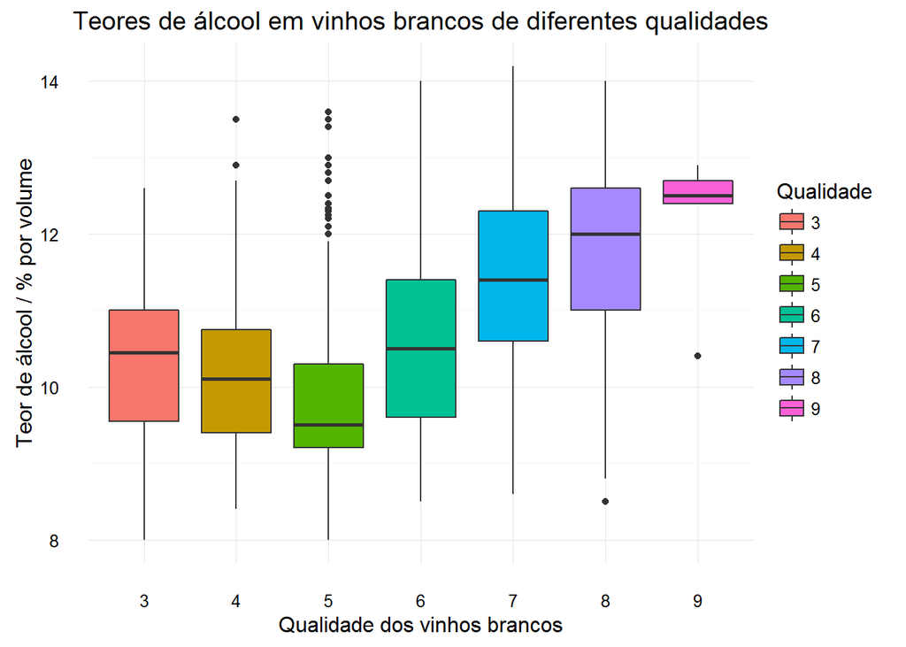

##### **5.1.1 Descrição do Primeiro Gráfico**

O boxplot apresenta um compilado final da relação positiva existente entre `alcohol` e `quality` . É possível constatar pelo gráfico que uma tendência crescente de álcool a medida que a qualidade dos vinhos aumenta. Apesar do intervalo entre 3 e 5 de `quality` haver uma redução do valor mediano de `alcohol`, a tendência geral do conjunto de dados é de aumento da mediana de `alcohol`. É interessante observar a robustez da mediana frente a valores extremos para o caso dos vinhos de classificação 5, essa categoria apresenta diversos vinhos com altos teores de `alcohol`, todavia, a mediana desses vinhos é menor do que aqueles vinhos com classificação 3 e 4.

##### **5.2 Segundo Gráfico**

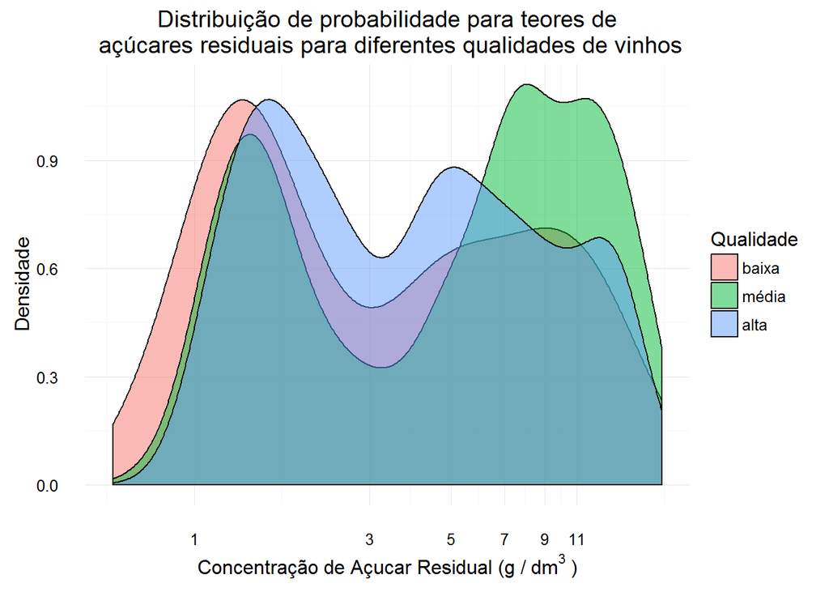

##### **5.2.1 Descrição do Segundo Gráfico**

O gráfico acima representa a função de distribuição de probabilidade para a variável `residual.sugar`. Essa característica físico-química quantifica o teor de açucar proveninente das uvas que estão presentes após o término da fermentação do vinho. Dessa forma, uma maior quantidade de açucar resulta em um vinho mais doce, enquanto menos resultará em vinhos mais secos. Dessa forma, há existencia de dois picos de `residual.sugar` para cada categoria de `quality.sense` nos informa que não há um padrão de qualidade **baixa** ou **alta** no que diz respeito ao vinho ser seco ou doce.

##### **5.3 Terceiro Gráfico**

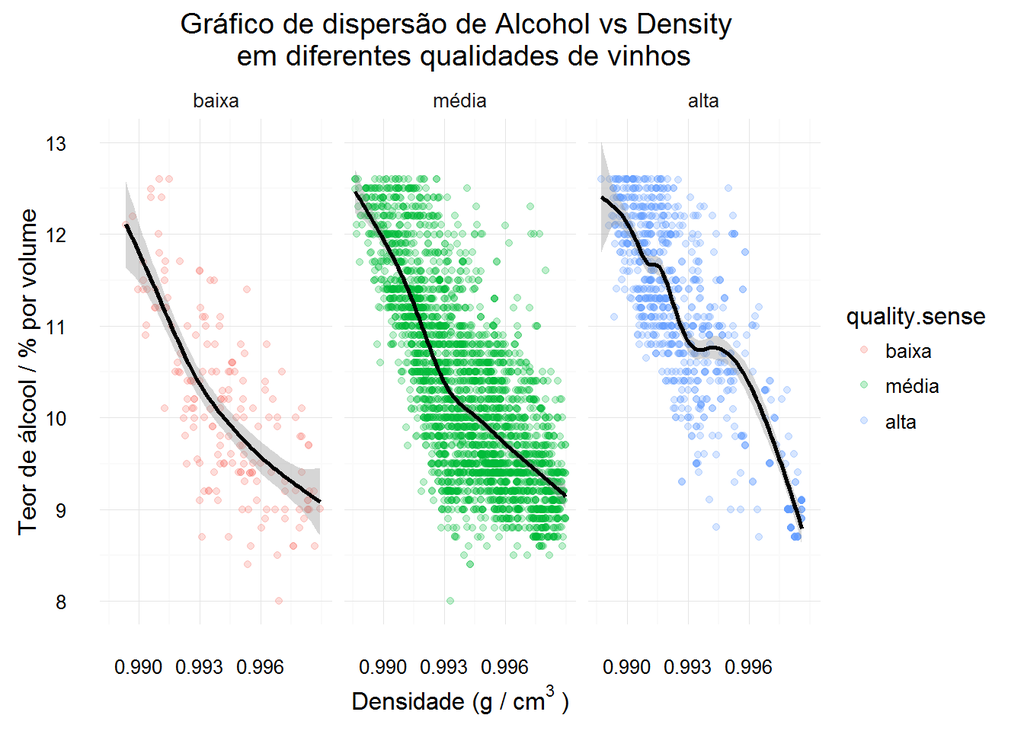

##### **5.3.1 Descrição do Terceiro Gráfico**

O gráfico apresenta a relação existente entre as variáveis `alcohol` e `density` que possuem um coeficiente de correlação de **-0.78** mostrando a forte relação inversa entre as variáveis. Desse modo, pela adição de mais uma dimensão no gráfico (`quality.sense`) foi possível constatar que essa tendência dos dados é semelhante independente da qualidade do vinho, ressaltando, que é possível ver uma maior concentração de vinhos avaliados como alta em menores valores de `density`, e consequentemente, maiores valores de `alcohol`.

#### **6. Reflexão**

Foi analisado um *dataset* que contém informações relativas as notas atribuídas por especialistas a diferentes vinhos branco, além de informações relativas a propriedades fisíco-químicas dessas bebidas. Foi realizado uma análise exploratória de modo verificar a existência de relações entre as propriedades físico-químicas do vinho e as notas atribuídas pelos especialistas.

A análise foi feito utilizando o *package ggplot2* e foi possível verificar que maiores teores de álcool do vinhos estavam associados aos vinhos de maior qualidade. Ainda foi possível identificar por um gráfico de distribuição de probabilidade para a variável `residual.sugar` constatar que não há um padrão de maior qualidade associado a vinhos que sejam doces ou secos. Além disso, foi observado uma preponderência de vinhos com qualidade alta possuírem menos valores de `density` .

Além disso, dos aproxidamente 5000 vinhos disponíveis para análise a grande maioria foram classificados entre 5 e 7 em uma escala até 10. Foi tentado construir modelos lineares para predizer a qualidade dos vinhos a partir de suas propriedades físico-químicas, todavia, os modelos não tiveram bons ajustes.

Um dos pressupostos para o bom desempenho de um modelo de regressão linear é que exista uma relação linear entre as variáveis dependente e a independente, e como apresentado ao longo da análise essa condição não é satisfeita para muitas variáveis analisadas. Além disso, esse tipo de modelo é muito sensível a presença de outliers, que também foi possível identificar a partir dos boxplots apresentados.

Além disso, dentro dos requisitos para um bom ajuste é a homogeneidade de variâncias, por exemplo, por meio dos boxplots de `alcohol` vs `quality` e `total.sulfur.dioxide` vs `quality` é possível identificar diferentes padrões de dispersão dos dados em diferentes níveis de `quality`. Desse modo, essas observações são indícios de heterocedasticidade, possivelmente contribuindo para um ajuste não adequado do modelo aos dados.

Desse modo, propõe em trabalho posterior a tentativa de utilizar transformações nas variáveis disponívels, bem como o uso de algoritmos não-lineares para modelagem dos dados na tentativa de obter melhores resultados quanto ao ajuste dos dados disponíveis.

#### **7. Bibliografia**

- http://docs.ggplot2.org/current/
- https://www.winecurmudgeon.com/residual-sugar-in-wine-with-charts-and-graphs/
- http://www.aromadictionary.com/articles/sulfurdioxide_article.html
- http://www.wineskills.co.uk/winemaking/winemaking-knowledge-base/chemical-composition